# Replication Code

2023-05-26

## Load Packages

```r
library(tidyverse)
theme_set(theme_minimal())
library(patchwork)
library(MASS)
library(sjPlot)
library(texreg)

# install.packages("https://cran.r-project.org/src/contrib/Archive/Zelig/Zelig_4.2-1.tar.gz",
#                  repos=NULL,
#                  type="source")
# install.packages("sandwich")
library(Zelig)
```

## Load Data

```r
d <- read_rds("Replication_Data.rds")
```

## Figure 1: Spatial distribution of state-based conflicts and malaria risk

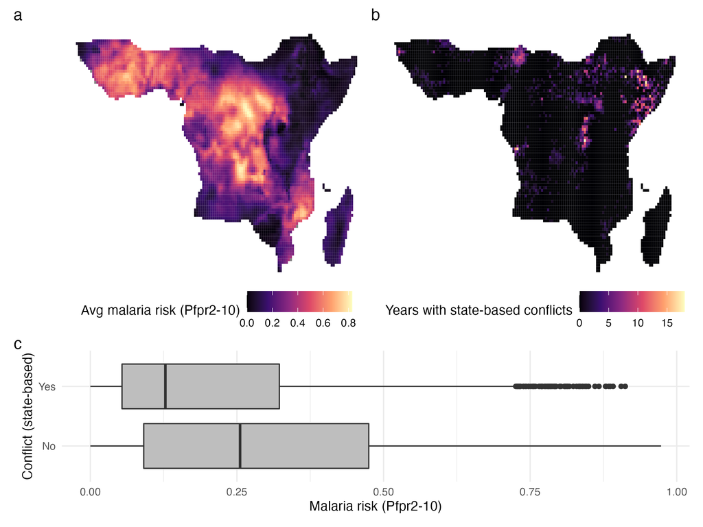

```r
p1 <- d %>%
  group_by(`Grid ID`, Lon, Lat) %>%
  summarise(`Avg malaria risk (Pfpr2-10)` = mean(`Malaria risk (Pfpr2-10)`)) %>%
  ggplot(aes(x = Lon, y = Lat, fill = `Avg malaria risk (Pfpr2-10)`)) +
  geom_tile() +
  scale_fill_viridis_c(option = "A") +
  theme_void() +
  theme(legend.position = "bottom")

p2 <- d %>%
  group_by(`Grid ID`, Lon, Lat) %>%
  summarise(`Years with state-based conflicts` = sum(`Conflicts occurrence (state-based)`)) %>%
  ggplot(aes(x = Lon, y = Lat, fill = `Years with state-based conflicts`)) +
  geom_tile() +
  scale_fill_viridis_c(option = "A") +
  theme_void() +
  theme(legend.position = "bottom")

p3 <- d %>%
  mutate(`Conflict (state-based)` = ifelse(`Conflicts occurrence (state-based)` == 1, "Yes", "No")) %>%
  ggplot(aes(x = `Conflict (state-based)`, y = `Malaria risk (Pfpr2-10)`)) +
  geom_boxplot(fill = 'grey') +
  coord_flip()

p_merge <- (p1 | p2) / p3 +
  plot_layout(height = c(2, 1)) + plot_annotation(tag_levels = "a")

dir.create("Out_Figures_Tables/")
ggsave("Out_Figures_Tables/Figure_1.png", width = 8, height = 6)
```

## Calculate Spatial Lag

```r
source("Helper/calculate_spatial_lag.R")
```

## Table 1 and A1

Note: As discussed in the article, Table 1 contains highlights of Table A1. It is not directly generated from code. The code below generates Table A1.

```r
# Prepare data for statistical analysis
source("Helper/prepare_data_for_regression.R")

# Run regressions
DV <- "Conflicts occurrence (state-based)"
EV <- "Malaria risk (Pfpr2-10)"
source("Helper/fit_models_logit.R")
```

```r
# Make summary table
htmlreg(models, omit.coef = "Country|Year",
        caption = sprintf("%s ~ %s", DV, EV),
        caption.above = TRUE,
        stars = c(0.01, 0.05, 0.10),
        booktabs = TRUE,
        custom.model.names = names(models),
        file = "Out_Figures_Tables/Table_1_A1.html"
)

htmlreg(models, omit.coef = "Country|Year",
        caption = sprintf("%s ~ %s", DV, EV),
        caption.above = TRUE,
        stars = c(0.01, 0.05, 0.10),
        booktabs = TRUE,
        custom.model.names = names(models)
)
```

Conflicts occurrence (state-based) ~ Malaria risk (Pfpr2-10)

1. AR1
2. Malaria
3. Rough
4. Dev
5. SC
6. HM

(Intercept)

-4.73***

-4.70***

-5.07***

-5.05***

-5.02***

-4.97***

(0.14)

(0.14)

(0.18)

(0.18)

(0.18)

(0.18)

`Conflicts occurrence (state-based) tlag`

2.54***

2.53***

2.50***

2.47***

2.44***

2.40***

(0.06)

(0.06)

(0.07)

(0.07)

(0.07)

(0.07)

`Conflicts occurrence (state-based) splag`

7.22***

7.17***

7.53***

7.69***

7.55***

7.51***

(0.13)

(0.14)

(0.16)

(0.16)

(0.16)

(0.16)

`Malaria risk (Pfpr2-10)`

-0.21***

-0.21***

-0.18***

-0.18***

-0.19***

(0.04)

(0.05)

(0.05)

(0.05)

(0.05)

`Prop. forest area`

0.12***

0.12***

0.13***

0.13***

(0.03)

(0.03)

(0.03)

(0.03)

`Prop. mountainous area`

0.05

0.05

0.03

0.02

(0.04)

(0.04)

(0.04)

(0.04)

`Precipitation total`

0.04

0.01

0.00

0.01

(0.03)

(0.03)

(0.03)

(0.03)

`Nightlight (mean)`

0.12***

0.11***

0.11***

(0.03)

(0.03)

(0.03)

`Prop. urban area`

0.03

0.00

-0.00

(0.03)

(0.03)

(0.03)

Population

0.07**

0.10***

0.09***

(0.03)

(0.03)

(0.03)

`Area irrigated`

0.05**

0.07***

0.06**

(0.02)

(0.02)

(0.02)

`Distance to border`

-0.16***

-0.13***

(0.04)

(0.04)

`Distance to capital`

0.14***

0.13***

(0.04)

(0.04)

`Refugee camps`

0.13***

(0.02)

AIC

14692.28

14669.84

11310.50

11224.78

11185.40

11151.77

BIC

15255.65

15242.72

11892.36

11844.01

11823.39

11799.14

Log Likelihood

-7287.14

-7274.92

-5593.25

-5546.39

-5524.70

-5506.88

Deviance

14574.28

14549.84

11186.50

11092.78

11049.40

11013.77

Num. obs.

103645

103567

87977

87746

87746

87746

***p < 0.01; **p < 0.05; *p < 0.1

# Figure 2

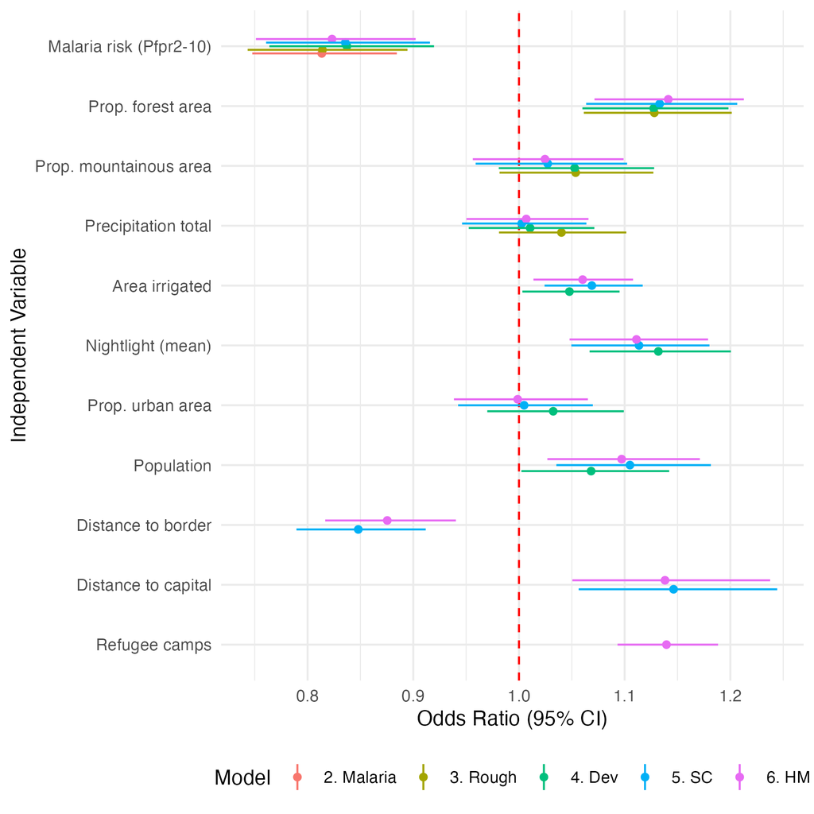

```r
var_select <- c("Malaria risk (Pfpr2-10)",
                "Prop. forest area", "Prop. mountainous area",
                "Precipitation total", "Area irrigated",
                "Nightlight (mean)", "Prop. urban area", "Population",
                "Distance to border", "Distance to capital",
                "Refugee camps")

ci_df_s <- ci_df %>%
  mutate(variable = str_remove_all(variable, "`")) %>%
  filter(variable %in% var_select) %>%
  mutate(variable = factor(variable,
                           levels = rev(var_select)))

p <- ci_df_s %>%
  rename("Model" = "model") %>%
  ggplot(aes(color = Model)) +
  geom_hline(yintercept=1, linetype = "dashed", color = "red") +
  geom_point(aes(y = `50%`, x = variable), position=position_dodge(width=0.3)) +
  geom_linerange(aes(x = variable, ymin = `2.5%`, ymax = `97.5%`),
                 position=position_dodge(width=0.3)) +
  ylab("Odds Ratio (95% CI)") + xlab("Independent Variable") +
  coord_flip() +
  theme_minimal() +
  theme(legend.position = "bottom")

ggsave("Out_Figures_Tables/Figure_2.png", plot = p, width = 6, height = 6)
```

## Figure 3

```r
# Prepare Data
source("Helper/prepare_data_for_regression_south_sudan.R")

# Fit models with South Sudan subset
DV <- "Conflicts occurrence (state-based)"
EV <- "Malaria risk (Pfpr2-10)"
source("Helper/fit_models_logit_south_sudan.R")
```

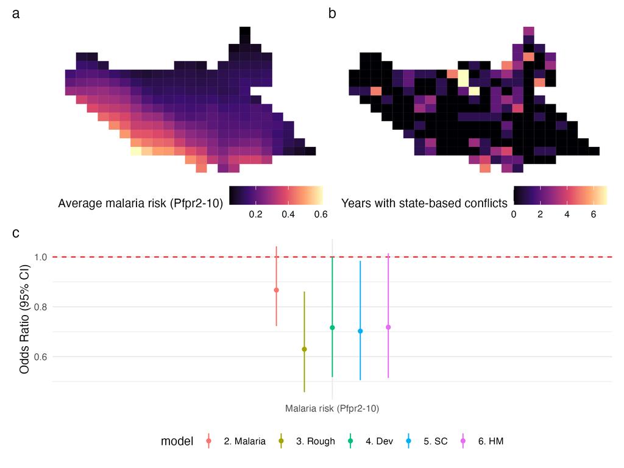

```r
p1 <- d %>%
  filter(Country == "South Sudan") %>%
  group_by(`Grid ID`, Lon, Lat) %>%
  summarise(`Average malaria risk (Pfpr2-10)` = mean(`Malaria risk (Pfpr2-10)`)) %>%
  ggplot(aes(x = Lon, y = Lat, fill = `Average malaria risk (Pfpr2-10)`)) +
  geom_tile() +
  scale_fill_viridis_c(option = "A") +
  theme_void() +
  theme(legend.position = "bottom")

p2 <- d %>%
  group_by(`Grid ID`, Lon, Lat) %>%
  filter(Country == "South Sudan") %>%
  summarise(`Years with state-based conflicts` = sum(`Conflicts occurrence (state-based)`)) %>%
  ggplot(aes(x = Lon, y = Lat, fill = `Years with state-based conflicts`)) +
  geom_tile() +
  scale_fill_viridis_c(option = "A") +
  theme_void() +
  theme(legend.position = "bottom")

var_select <- c("Malaria risk (Pfpr2-10)")

ci_df_s <- ci_df %>%
  mutate(variable = str_remove_all(variable, "`")) %>%
  filter(variable %in% var_select) %>%
  mutate(variable = factor(variable,
                           levels = rev(var_select)))

p3 <- ci_df_s %>%
  ggplot(aes(color = model)) +
  geom_hline(yintercept=1, linetype = "dashed", color = "red") +
  geom_point(aes(y = `50%`, x = variable), position=position_dodge(width=0.3)) +
  geom_linerange(aes(x = variable, ymin = `2.5%`, ymax = `97.5%`),
                 position=position_dodge(width=0.3)) +
  ylab("Odds Ratio (95% CI)") + xlab("Independent Variable") +
  theme_minimal() +
  theme(legend.position = "bottom") +
  theme(axis.title.x = element_blank())

p_merge <- (p1 | p2) / p3 + plot_annotation(tag_levels = "a")

ggsave("Out_Figures_Tables/Figure_3.png", plot = p_merge, width = 8, height = 6)
```

## Table A2: Removing Temporal Lags

```r
# Prepare data for statistical analysis
source("Helper/prepare_data_for_regression.R")

# Run regressions
DV <- "Conflicts occurrence (state-based)"
EV <- "Malaria risk (Pfpr2-10)"
source("Helper/fit_models_logit_wo_tlag.R")
```

```r
# Make summary table
htmlreg(models, omit.coef = "Country|Year",
        caption = sprintf("%s ~ %s", DV, EV),
        caption.above = TRUE,
        stars = c(0.01, 0.05, 0.10),
        booktabs = TRUE,
        custom.model.names = names(models),
        file = "Out_Figures_Tables/Table_A2.html"
)

htmlreg(models, omit.coef = "Country|Year",
        caption = sprintf("%s ~ %s", DV, EV),
        caption.above = TRUE,
        stars = c(0.01, 0.05, 0.10),
        booktabs = TRUE,
        custom.model.names = names(models)
)
```

Conflicts occurrence (state-based) ~ Malaria risk (Pfpr2-10)

1. AR1
2. Malaria
3. Rough
4. Dev
5. SC
6. HM

(Intercept)

-4.48***

-4.45***

-4.89***

-4.85***

-4.84***

-4.78***

(0.13)

(0.13)

(0.18)

(0.18)

(0.18)

(0.18)

`Conflicts occurrence (state-based) splag`

8.56***

8.49***

8.81***

8.96***

8.77***

8.68***

(0.12)

(0.13)

(0.15)

(0.15)

(0.15)

(0.15)

`Malaria risk (Pfpr2-10)`

-0.23***

-0.24***

-0.21***

-0.20***

-0.22***

(0.04)

(0.05)

(0.05)

(0.04)

(0.05)

`Prop. forest area`

0.16***

0.16***

0.16***

0.17***

(0.03)

(0.03)

(0.03)

(0.03)

`Prop. mountainous area`

0.09***

0.09***

0.06*

0.05

(0.03)

(0.03)

(0.03)

(0.03)

`Precipitation total`

0.02

-0.01

-0.02

-0.01

(0.03)

(0.03)

(0.03)

(0.03)

`Nightlight (mean)`

0.12***

0.10***

0.09***

(0.03)

(0.03)

(0.03)

`Prop. urban area`

0.03

0.00

-0.01

(0.03)

(0.03)

(0.03)

Population

0.08***

0.12***

0.11***

(0.03)

(0.03)

(0.03)

`Area irrigated`

0.05***

0.08***

0.06***

(0.02)

(0.02)

(0.02)

`Distance to border`

-0.20***

-0.16***

(0.03)

(0.04)

`Distance to capital`

0.17***

0.16***

(0.04)

(0.04)

`Refugee camps`

0.18***

(0.02)

AIC

16480.44

16447.61

12579.17

12464.04

12395.52

12316.34

BIC

17034.27

17010.94

13151.65

13073.88

13024.13

12954.33

Log Likelihood

-8182.22

-8164.81

-6228.59

-6167.02

-6130.76

-6090.17

Deviance

16364.44

16329.61

12457.17

12334.04

12261.52

12180.34

Num. obs.

103645

103567

87977

87746

87746

87746

***p < 0.01; **p < 0.05; *p < 0.1

## Table A3: Rare Event Logistic Regression

```r
# Prepare data for statistical analysis
source("Helper/prepare_data_for_regression.R")

# Run regressions
DV <- "Conflicts occurrence (state-based)"
EV <- "Malaria risk (Pfpr2-10)"
source("Helper/fit_models_relogit.R")
```

```r
# Make summary table
htmlreg(models, omit.coef = "Country|Year",
        caption = sprintf("%s ~ %s", DV, EV),
        caption.above = TRUE,
        stars = c(0.01, 0.05, 0.10),
        booktabs = TRUE,
        custom.model.names = names(models),
        file = "Out_Figures_Tables/Table_A3.html"
)

htmlreg(models, omit.coef = "Country|Year",
        caption = sprintf("%s ~ %s", DV, EV),
        caption.above = TRUE,
        stars = c(0.01, 0.05, 0.10),
        booktabs = TRUE,
        custom.model.names = names(models)
)
```

Conflicts occurrence (state-based) ~ Malaria risk (Pfpr2-10)

1. AR1
2. Malaria
3. Rough
4. Dev
5. SC
6. HM

(Intercept)

-4.72***

-4.69***

-5.05***

-5.03***

-5.00***

-4.95***

(0.14)

(0.14)

(0.18)

(0.18)

(0.18)

(0.18)

`Conflicts occurrence (state-based) tlag`

2.53***

2.52***

2.49***

2.46***

2.43***

2.39***

(0.06)

(0.06)

(0.07)

(0.07)

(0.07)

(0.07)

`Conflicts occurrence (state-based) splag`

7.20***

7.15***

7.51***

7.66***

7.51***

7.48***

(0.13)

(0.14)

(0.16)

(0.16)

(0.16)

(0.16)

`Malaria risk (Pfpr2-10)`

-0.21***

-0.21***

-0.18***

-0.18***

-0.19***

(0.04)

(0.05)

(0.05)

(0.05)

(0.05)

`Prop. forest area`

0.12***

0.12***

0.13***

0.13***

(0.03)

(0.03)

(0.03)

(0.03)

`Prop. mountainous area`

0.05

0.05

0.03

0.02

(0.04)

(0.04)

(0.04)

(0.04)

`Precipitation total`

0.04

0.01

0.00

0.01

(0.03)

(0.03)

(0.03)

(0.03)

`Nightlight (mean)`

0.12***

0.11***

0.11***

(0.03)

(0.03)

(0.03)

`Prop. urban area`

0.03

0.01

-0.00

(0.03)

(0.03)

(0.03)

Population

0.07**

0.10***

0.09***

(0.03)

(0.03)

(0.03)

`Area irrigated`

0.05**

0.07***

0.06***

(0.02)

(0.02)

(0.02)

`Distance to border`

-0.16***

-0.13***

(0.04)

(0.04)

`Distance to capital`

0.14***

0.13***

(0.04)

(0.04)

`Refugee camps`

0.13***

(0.02)

AIC

14692.28

14669.84

11310.50

11224.78

11185.40

11151.77

BIC

15255.65

15242.72

11892.36

11844.01

11823.39

11799.14

Log Likelihood

-7287.14

-7274.92

-5593.25

-5546.39

-5524.70

-5506.88

Deviance

14574.28

14549.84

11186.50

11092.78

11049.40

11013.77

Num. obs.

103645

103567

87977

87746

87746

87746

***p < 0.01; **p < 0.05; *p < 0.1

## Table A4: Alternative Independent Variable (Pf Incidence)

```r
# Prepare data for statistical analysis
source("Helper/prepare_data_for_regression.R")

# Run regressions
DV <- "Conflicts occurrence (state-based)"
EV <- "Malaria risk (Pf Incidence)"
source("Helper/fit_models_logit.R")
```

```r
# Make summary table
htmlreg(models, omit.coef = "Country|Year",
        caption = sprintf("%s ~ %s", DV, EV),
        caption.above = TRUE,
        stars = c(0.01, 0.05, 0.10),
        booktabs = TRUE,
        custom.model.names = names(models),
        file = "Out_Figures_Tables/Table_A4.html"
)

htmlreg(models, omit.coef = "Country|Year",
        caption = sprintf("%s ~ %s", DV, EV),
        caption.above = TRUE,
        stars = c(0.01, 0.05, 0.10),
        booktabs = TRUE,
        custom.model.names = names(models)
)
```

Conflicts occurrence (state-based) ~ Malaria risk (Pf Incidence)

1. AR1
2. Malaria
3. Rough
4. Dev
5. SC
6. HM

(Intercept)

-4.73***

-5.11***

-5.05***

-5.03***

-5.00***

-4.95***

(0.14)

(0.18)

(0.18)

(0.18)

(0.18)

(0.18)

`Conflicts occurrence (state-based) tlag`

2.54***

2.52***

2.51***

2.47***

2.44***

2.41***

(0.06)

(0.06)

(0.07)

(0.07)

(0.07)

(0.07)

`Conflicts occurrence (state-based) splag`

7.22***

7.08***

7.53***

7.70***

7.54***

7.51***

(0.13)

(0.14)

(0.16)

(0.16)

(0.16)

(0.17)

`Malaria risk (Pf Incidence)`

-0.19***

-0.19***

-0.14***

-0.15***

-0.16***

(0.04)

(0.05)

(0.05)

(0.05)

(0.05)

`Prop. forest area`

0.12***

0.12***

0.13***

0.13***

(0.03)

(0.03)

(0.03)

(0.03)

`Prop. mountainous area`

0.06

0.06*

0.03

0.03

(0.04)

(0.04)

(0.04)

(0.04)

`Precipitation total`

0.04

0.01

-0.00

0.00

(0.03)

(0.03)

(0.03)

(0.03)

`Nightlight (mean)`

0.12***

0.11***

0.10***

(0.03)

(0.03)

(0.03)

`Prop. urban area`

0.03

0.01

-0.00

(0.03)

(0.03)

(0.03)

Population

0.07*

0.10***

0.09***

(0.03)

(0.03)

(0.03)

`Area irrigated`

0.05**

0.07***

0.06**

(0.02)

(0.02)

(0.02)

`Distance to border`

-0.17***

-0.14***

(0.04)

(0.04)

`Distance to capital`

0.14***

0.13***

(0.04)

(0.04)

`Refugee camps`

0.13***

(0.02)

AIC

14692.28

13767.20

11314.17

11230.12

11190.03

11157.34

BIC

15255.65

14327.31

11896.02

11849.34

11828.01

11804.70

Log Likelihood

-7287.14

-6824.60

-5595.08

-5549.06

-5527.01

-5509.67

Deviance

14574.28

13649.20

11190.17

11098.12

11054.03

11019.34

Num. obs.

103645

98063

87962

87735

87735

87735

***p < 0.01; **p < 0.05; *p < 0.1

# Table A5: Alternative Dependent Variable: ACLED Battles

```r
# Prepare data for statistical analysis
source("Helper/prepare_data_for_regression.R")

# Run regressions
DV <- "Conflicts occurrence (Battles, ACLED)"
EV <- "Malaria risk (Pfpr2-10)"
source("Helper/fit_models_logit.R")
```

```r
# Make summary table
htmlreg(models, omit.coef = "Country|Year",
        caption = sprintf("%s ~ %s", DV, EV),
        caption.above = TRUE,
        stars = c(0.01, 0.05, 0.10),
        booktabs = TRUE,
        custom.model.names = names(models),
        file = "Out_Figures_Tables/Table_A4.html"
)

htmlreg(models, omit.coef = "Country|Year",
        caption = sprintf("%s ~ %s", DV, EV),
        caption.above = TRUE,
        stars = c(0.01, 0.05, 0.10),
        booktabs = TRUE,
        custom.model.names = names(models)
)
```

Conflicts occurrence (Battles, ACLED) ~ Malaria risk (Pfpr2-10)

1. AR1
2. Malaria
3. Rough
4. Dev
5. SC
6. HM

(Intercept)

-5.72***

-5.67***

-5.64***

-5.96***

-5.93***

-5.84***

(0.18)

(0.18)

(0.19)

(0.21)

(0.21)

(0.21)

`Conflicts occurrence (Battles, ACLED) tlag`

2.96***

2.94***

2.84***

2.14***

2.14***

2.10***

(0.04)

(0.04)

(0.05)

(0.05)

(0.05)

(0.05)

`Conflicts occurrence (Battles, ACLED) splag`

4.09***

3.98***

3.59***

2.80***

2.81***

2.87***

(0.12)

(0.12)

(0.14)

(0.14)

(0.14)

(0.14)

`Malaria risk (Pfpr2-10)`

-0.35***

-0.38***

-0.23***

-0.22***

-0.22***

(0.04)

(0.04)

(0.04)

(0.04)

(0.04)

`Prop. forest area`

0.07***

0.06***

0.06***

0.07***

(0.02)

(0.02)

(0.02)

(0.02)

`Prop. mountainous area`

0.04*

0.11***

0.11***

0.09***

(0.02)

(0.02)

(0.02)

(0.02)

`Precipitation total`

0.10***

0.01

0.00

0.01

(0.02)

(0.02)

(0.02)

(0.02)

`Nightlight (mean)`

0.14***

0.14***

0.14***

(0.02)

(0.02)

(0.02)

`Prop. urban area`

0.18***

0.18***

0.15***

(0.02)

(0.02)

(0.02)

Population

0.42***

0.42***

0.41***

(0.02)

(0.02)

(0.02)

`Area irrigated`

0.05***

0.06***

0.05***

(0.01)

(0.01)

(0.01)

`Distance to border`

-0.09***

-0.05*

(0.03)

(0.03)

`Distance to capital`

-0.05

-0.06*

(0.04)

(0.04)

`Refugee camps`

0.19***

(0.02)

AIC

24778.69

24677.91

21465.81

19817.50

19809.94

19673.87

BIC

25342.06

25250.78

22047.67

20436.72

20447.93

20321.24

Log Likelihood

-12330.34

-12278.95

-10670.90

-9842.75

-9836.97

-9767.93

Deviance

24660.69

24557.91

21341.81

19685.50

19673.94

19535.87

Num. obs.

103645

103567

87977

87746

87746

87746

***p < 0.01; **p < 0.05; *p < 0.1

## Table A6: South Sudan Subset (Year Fixed Effect)

```r
# Prepare Data
source("Helper/prepare_data_for_regression_south_sudan.R")

# Fit models with South Sudan subset
DV <- "Conflicts occurrence (state-based)"
EV <- "Malaria risk (Pfpr2-10)"
source("Helper/fit_models_logit_south_sudan.R")
```

```r
# Make summary table
htmlreg(models, omit.coef = "Country|Year",
        caption = sprintf("%s ~ %s", DV, EV),
        caption.above = TRUE,
        stars = c(0.01, 0.05, 0.10),
        booktabs = TRUE,
        custom.model.names = names(models),
        file = "Out_Figures_Tables/Table_A6.html"
)

htmlreg(models, omit.coef = "Country|Year",
        caption = sprintf("%s ~ %s", DV, EV),
        caption.above = TRUE,
        stars = c(0.01, 0.05, 0.10),
        booktabs = TRUE,
        custom.model.names = names(models)
)
```

Conflicts occurrence (state-based) ~ Malaria risk (Pfpr2-10)

1. AR1
2. Malaria
3. Rough
4. Dev
5. SC
6. HM

(Intercept)

-3.01***

-3.00***

-3.14***

-2.99***

-3.14***

-3.04***

(0.28)

(0.28)

(0.30)

(0.35)

(0.56)

(0.57)

`Conflicts occurrence (state-based) tlag`

2.15***

2.12***

2.08***

1.85***

1.84***

1.82***

(0.21)

(0.21)

(0.22)

(0.23)

(0.23)

(0.23)

`Conflicts occurrence (state-based) splag`

4.58***

4.51***

4.24***

4.26***

4.30***

4.29***

(0.58)

(0.58)

(0.60)

(0.62)

(0.63)

(0.63)

`Malaria risk (Pfpr2-10)`

-0.14

-0.46***

-0.33**

-0.35**

-0.33*

(0.09)

(0.16)

(0.17)

(0.17)

(0.17)

`Prop. forest area`

0.19**

0.09

0.08

0.05

(0.08)

(0.08)

(0.08)

(0.09)

`Prop. mountainous area`

-0.12

-0.43**

-0.44**

-0.41**

(0.13)

(0.18)

(0.18)

(0.18)

`Precipitation total`

0.34*

0.24

0.28

0.28

(0.18)

(0.20)

(0.21)

(0.21)

`Nightlight (mean)`

0.14

0.13

0.14

(0.17)

(0.17)

(0.17)

`Prop. urban area`

0.18***

0.18***

0.15**

(0.06)

(0.06)

(0.07)

Population

0.46***

0.47***

0.46***

(0.12)

(0.12)

(0.12)

`Area irrigated`

0.19***

0.18***

0.17**

(0.06)

(0.07)

(0.07)

`Distance to border`

-0.02

0.01

(0.11)

(0.12)

`Distance to capital`

0.08

0.07

(0.18)

(0.18)

`Refugee camps`

0.20*

(0.11)

AIC

956.54

956.13

901.57

874.26

877.88

876.58

BIC

1017.26

1022.37

983.05

977.46

991.95

996.08

Log Likelihood

-467.27

-466.07

-435.79

-418.13

-417.94

-416.29

Deviance

934.54

932.13

871.57

836.26

835.88

832.58

Num. obs.

1845

1845

1689

1689

1689

1689

***p < 0.01; **p < 0.05; *p < 0.1

## Table A7: South Sudan Subset (Year-Grid Two-Way Fixed Effect)

```r
# Prepare Data
source("Helper/prepare_data_for_regression_south_sudan.R")

# Fit models with South Sudan subset
DV <- "Conflicts occurrence (state-based)"
EV <- "Malaria risk (Pfpr2-10)"
source("Helper/fit_models_logit_south_sudan.R")
```

```r
# Make summary table
htmlreg(models_GridFE, omit.coef = "GridID|Year",
        caption = sprintf("%s ~ %s", DV, EV),
        caption.above = TRUE,
        stars = c(0.01, 0.05, 0.10),
        booktabs = TRUE,
        custom.model.names = names(models),
        file = "Out_Figures_Tables/Table_A7.html"
)

htmlreg(models_GridFE, omit.coef = "GridID|Year",
        caption = sprintf("%s ~ %s", DV, EV),
        caption.above = TRUE,
        stars = c(0.01, 0.05, 0.10),
        booktabs = TRUE,
        custom.model.names = names(models)
)
```

Conflicts occurrence (state-based) ~ Malaria risk (Pfpr2-10)

1. AR1
2. Malaria
3. Rough
4. Dev
5. SC
6. HM

(Intercept)

-0.77

0.74

-0.86

-2.54*

-4.43**

-4.50**

(0.88)

(1.35)

(0.90)

(1.31)

(1.80)

(1.81)

`Conflicts occurrence (state-based) tlag`

-0.25

-0.23

-0.23

-0.30

-0.30

-0.30

(0.29)

(0.29)

(0.30)

(0.31)

(0.31)

(0.31)

`Conflicts occurrence (state-based) splag`

7.18***

6.96***

6.67***

5.71***

5.47***

5.44***

(1.01)

(1.02)

(1.07)

(1.10)

(1.11)

(1.11)

`Malaria risk (Pfpr2-10)`

-0.55*

-0.48

-0.87**

-1.10**

-1.09**

(0.33)

(0.35)

(0.43)

(0.48)

(0.49)

`Prop. forest area`

-0.24*

-0.23*

-0.24*

-0.24*

(0.13)

(0.14)

(0.14)

(0.14)

`Prop. mountainous area`

1.27

-0.51

0.54

0.62

(1.22)

(1.73)

(1.84)

(1.85)

`Precipitation total`

0.05

0.24

0.14

0.13

(0.45)

(0.47)

(0.48)

(0.48)

`Nightlight (mean)`

0.57*

0.53*

0.53*

(0.30)

(0.30)

(0.30)

`Prop. urban area`

1.76

2.24

2.10

(3.30)

(3.14)

(3.12)

Population

1.76**

1.90***

1.88***

(0.70)

(0.71)

(0.71)

`Area irrigated`

0.31*

0.30*

0.31*

(0.16)

(0.16)

(0.17)

`Distance to border`

0.77**

0.76**

(0.35)

(0.35)

`Distance to capital`

0.73

0.73

(0.45)

(0.45)

`Refugee camps`

-0.08

(0.19)

AIC

1017.36

1016.45

965.52

960.05

958.50

960.33

BIC

2204.21

2208.82

2149.68

2160.49

2169.81

2177.07

Log Likelihood

-293.68

-292.23

-264.76

-259.02

-256.25

-256.17

Deviance

587.36

584.45

529.52

518.05

512.50

512.33

Num. obs.

1845

1845

1689

1689

1689

1689

***p < 0.01; **p < 0.05; *p < 0.1